# Dissecting Spotify Valence

In this project we will try to dissect Spotify's valence metric, untangle the mystery behind it and propose how it is derived. This assignment was done as a project for the Practical Data Science course taught by Mr. Panos Louridas at the Athens University of Economics and Business.

Spotify uses a metric called *valence* to measure the happiness of a track. The metric itself, however, was not developed by Spotify. It was originally developed by Echo Nest, a company that was bought by Spotify in 2014. We don't know exactly how valence is calculated. Some details are given by a blog post, which you can find here:

https://web.archive.org/web/20170422195736/http://blog.echonest.com/post/66097438564/plotting-musics-emotional-valence-1950-2013

Our task is to untangle the mystery behind valence and propose how this is derived.

Spotify offers the following information that may be relevant to our task:

- [Get Track's Audio Features](https://developer.spotify.com/documentation/web-api/reference/#/operations/get-audio-features) and [Get Tracks' Audio Features](https://developer.spotify.com/documentation/web-api/reference/#/operations/get-several-audio-features).
- [Get Track's Audio Analysis](https://developer.spotify.com/documentation/web-api/reference/#/operations/get-audio-analysis).

We start by creating a Spotify account if we don't already have and logging into our dashboard.

[figure not shown]

We click on CREATE AN APP and choose the name and description of our App.

[figure not shown]

In the dashboard of our application we can see the Client ID and Client Secret that we will use to access the Spotify API. We should be careful when requesting data from the API as there are rate limits in place. If these limits are exceeded we will get 429 error responses from Spotify’s Web API.

Now that we have our credentials, we create a spotify_config.py file to store them and we are ready to connect to the service.

> The credentials stored in the spotify_config.py file are not encrypted so anyone with the file can access them. If we wanted to make this code public let's say in a GitHub repo, we would add spotify_config.py in the .gitignore file

```python
# Let's start with our imports
import pandas as pd
import numpy as np
import scipy.stats as stats
import statsmodels.api as sm

import re
from datetime import datetime

import os
import glob

import spotipy
from spotipy.oauth2 import SpotifyClientCredentials
from spotify_config import config

import matplotlib.pyplot as plt
import seaborn as sns

%matplotlib inline
```

Here we are creating a spotify client session so we can connect to the API.

```python
client_credentials_manager = SpotifyClientCredentials(config['client_id'],
                                                      config['client_secret'])
sp = spotipy.Spotify(client_credentials_manager=client_credentials_manager)
```

Next we need to get some song ids that we will use to get the data from the Spotify server. For that purpose we downloaded data for some countries and the world as a whole, for the period 2017-2019, from [here](https://doi.org/10.5281/zenodo.4778562) that were collected for the needs of the next paper.

> Gabriel P. Oliveira, Mariana O. Silva, Danilo B. Seufitelli, Anisio Lacerda, and Mirella M. Moro. Detecting Collaboration Profiles in Success-based Music Genre Networks. In Proceedings of the 21st International Society for Music Information Retrieval Conference (ISMIR 2020), 2020.

From the Zenodo page that we opened we download *charts.zip* and extract the content in our path.

[figure not shown]

Now let's run the code below to get the songs into a dataframe.

```python
header = 0
dfs = []
for file in glob.glob('Charts/*/201?/*.csv'):
    region = file.split('\\')[1]
    dates = re.findall('\d{4}-\d{2}-\d{2}', file.split('/')[-1])
    weekly_chart = pd.read_csv(file, header=header, sep='\t')
    weekly_chart['week_start'] = datetime.strptime(dates[0], '%Y-%m-%d')
    weekly_chart['week_end'] = datetime.strptime(dates[1], '%Y-%m-%d')
    weekly_chart['region'] = region
    dfs.append(weekly_chart)

all_charts = pd.concat(dfs)
all_charts
```

|  | position | song_id | song_name | artist | streams | last_week_position | weeks_on_chart | peak_position | position_status | week_start | week_end | region |
| --- | --- | --- | --- | --- | --- | --- | --- | --- | --- | --- | --- | --- |
| 0 | 1 | 5aAx2yezTd8zXrkmtKl66Z | Starboy | The Weeknd | 25734078 | NaN | 1 | 1 | new | 2016-12-30 | 2017-01-06 | global |
| 1 | 2 | 7BKLCZ1jbUBVqRi2FVlTVw | Closer | The Chainsmokers | 23519705 | NaN | 1 | 2 | new | 2016-12-30 | 2017-01-06 | global |
| 2 | 3 | 5knuzwU65gJK7IF5yJsuaW | Rockabye (feat. Sean Paul & Anne-Marie) | Clean Bandit | 21216399 | NaN | 1 | 3 | new | 2016-12-30 | 2017-01-06 | global |
| 3 | 4 | 4pdPtRcBmOSQDlJ3Fk945m | Let Me Love You | DJ Snake | 19852704 | NaN | 1 | 4 | new | 2016-12-30 | 2017-01-06 | global |
| 4 | 5 | 3NdDpSvN911VPGivFlV5d0 | I Don’t Wanna Live Forever (Fifty Shades Darke... | ZAYN | 18316326 | NaN | 1 | 5 | new | 2016-12-30 | 2017-01-06 | global |
| ... | ... | ... | ... | ... | ... | ... | ... | ... | ... | ... | ... | ... |
| 195 | 196 | 2nMZx7QHerfo4Wv37xNUEC | Wrapped in Red | Kelly Clarkson | 291064 | NaN | 1 | 196 | new | 2019-12-20 | 2019-12-27 | ca |
| 196 | 197 | 0e7ipj03S05BNilyu5bRzt | rockstar (feat. 21 Savage) | Post Malone | 290360 | 158.0 | 87 | 7 | -39 | 2019-12-20 | 2019-12-27 | ca |
| 197 | 198 | 0u2P5u6lvoDfwTYjAADbn4 | lovely (with Khalid) | Billie Eilish | 289022 | 170.0 | 66 | 29 | -28 | 2019-12-20 | 2019-12-27 | ca |
| 198 | 199 | 30SNjazZhzunhAWCjhdyyD | Christmas All Over Again | Tom Petty and the Heartbreakers | 288611 | NaN | 1 | 199 | new | 2019-12-20 | 2019-12-27 | ca |
| 199 | 200 | 7FGq80cy8juXBCD2nrqdWU | Eastside (with Halsey & Khalid) | benny blanco | 288079 | 136.0 | 55 | 11 | -64 | 2019-12-20 | 2019-12-27 | ca |

273600 rows × 12 columns

There are 273600 rows in the dataset but we care about the unique songs. We count them by id and we get 13880 unique songs.

```python
all_charts['song_id'].nunique()
```

```
13880
```

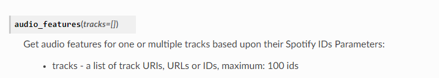

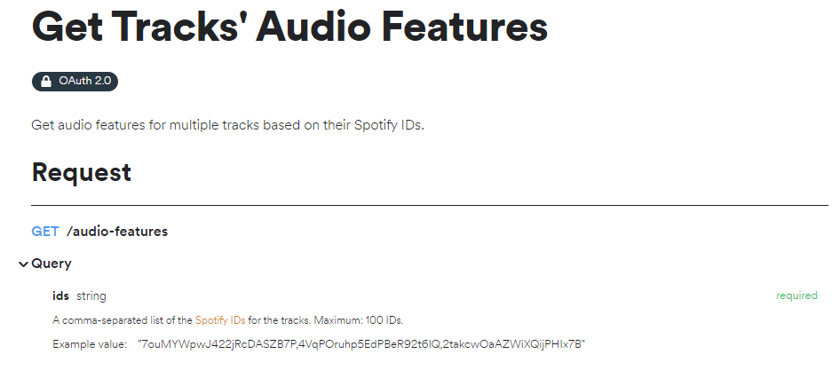

The *audio_features* method of the Spotipy library takes as an argument a list of length 100 at maximum. It is defined this way as the Spotify API has 100 limit of songs per request as seen in the above screenshots. Below is an example of a call to this method for 2 songs.

```python
sp.audio_features(['3js3wKPw8VxBWtcXtwyUnA', '4VVG3HBGaqSNZqIpmewIA6'])
```

```
[{'danceability': 0.798,
  'energy': 0.627,
  'key': 9,
  'loudness': -6.234,
  'mode': 1,
  'speechiness': 0.111,
  'acousticness': 0.263,
  'instrumentalness': 0,
  'liveness': 0.211,
  'valence': 0.762,
  'tempo': 149.989,
  'type': 'audio_features',
  'id': '3js3wKPw8VxBWtcXtwyUnA',
  'uri': 'spotify:track:3js3wKPw8VxBWtcXtwyUnA',
  'track_href': 'https://api.spotify.com/v1/tracks/3js3wKPw8VxBWtcXtwyUnA',
  'analysis_url': 'https://api.spotify.com/v1/audio-analysis/3js3wKPw8VxBWtcXtwyUnA',
  'duration_ms': 195947,
  'time_signature': 4},
 {'danceability': 0.777,
  'energy': 0.721,
  'key': 6,
  'loudness': -6.097,
  'mode': 1,
  'speechiness': 0.0719,
  'acousticness': 0.0774,
  'instrumentalness': 0,
  'liveness': 0.0801,
  'valence': 0.665,
  'tempo': 161.976,
  'type': 'audio_features',
  'id': '4VVG3HBGaqSNZqIpmewIA6',
  'uri': 'spotify:track:4VVG3HBGaqSNZqIpmewIA6',
  'track_href': 'https://api.spotify.com/v1/tracks/4VVG3HBGaqSNZqIpmewIA6',
  'analysis_url': 'https://api.spotify.com/v1/audio-analysis/4VVG3HBGaqSNZqIpmewIA6',
  'duration_ms': 205013,
  'time_signature': 4}]
```

Explanation of the audio features can be found in [Spotify's Web API Reference](https://developer.spotify.com/documentation/web-api/reference/#/operations/get-several-audio-features). Below the features that can be useful to us are listed:

- **acousticness**: A confidence measure from 0.0 to 1.0 of whether the track is acoustic. 1.0 represents high confidence the track is acoustic.
- **danceability**: Danceability describes how suitable a track is for dancing based on a combination of musical elements including tempo, rhythm stability, beat strength, and overall regularity. A value of 0.0 is least danceable and 1.0 is most danceable.
- **duration_ms**: The duration of the track in milliseconds.
- **energy**: Energy is a measure from 0.0 to 1.0 and represents a perceptual measure of intensity and activity. Typically, energetic tracks feel fast, loud, and noisy. For example, death metal has high energy, while a Bach prelude scores low on the scale. Perceptual features contributing to this attribute include dynamic range, perceived loudness, timbre, onset rate, and general entropy.
- **instrumentalness**: Predicts whether a track contains no vocals. "Ooh" and "aah" sounds are treated as instrumental in this context. Rap or spoken word tracks are clearly "vocal". The closer the instrumentalness value is to 1.0, the greater likelihood the track contains no vocal content. Values above 0.5 are intended to represent instrumental tracks, but confidence is higher as the value approaches 1.0.
- **key**: The key the track is in. Integers map to pitches using standard Pitch Class notation. E.g. 0 = C, 1 = C♯/D♭, 2 = D, and so on. If no key was detected, the value is -1.
- **liveness**: Detects the presence of an audience in the recording. Higher liveness values represent an increased probability that the track was performed live. A value above 0.8 provides strong likelihood that the track is live.
- **loudness**: The overall loudness of a track in decibels (dB). Loudness values are averaged across the entire track and are useful for comparing relative loudness of tracks. Loudness is the quality of a sound that is the primary psychological correlate of physical strength (amplitude). Values typically range between -60 and 0 db.
- **mode**: Mode indicates the modality (major or minor) of a track, the type of scale from which its melodic content is derived. Major is represented by 1 and minor is 0.
- **speechiness**: Speechiness detects the presence of spoken words in a track. The more exclusively speech-like the recording (e.g. talk show, audio book, poetry), the closer to 1.0 the attribute value. Values above 0.66 describe tracks that are probably made entirely of spoken words. Values between 0.33 and 0.66 describe tracks that may contain both music and speech, either in sections or layered, including such cases as rap music. Values below 0.33 most likely represent music and other non-speech-like tracks.
- **tempo**: The overall estimated tempo of a track in beats per minute (BPM). In musical terminology, tempo is the speed or pace of a given piece and derives directly from the average beat duration.
- **time_signature**: An estimated time signature. The time signature (meter) is a notational convention to specify how many beats are in each bar (or measure). The time signature ranges from 3 to 7 indicating time signatures of "3/4", to "7/4".
- **valence**: A measure from 0.0 to 1.0 describing the musical positiveness conveyed by a track. Tracks with high valence sound more positive (e.g. happy, cheerful, euphoric), while tracks with low valence sound more negative (e.g. sad, depressed, angry).

In order not to download the data everytime we run this notebook (doing the same calls over and over) we will save the created dataframe as csv later on. Here, we will check if the csv exists and if it does not we will download the data.

So, now we need to create a dictionary where the keys will be the song ids and the values will be the song features. Then, we download the song features at 100 size batches.

```python
if os.path.exists('valence.csv'):
    df = pd.read_csv('valence.csv')
else:
    features = {}
    all_track_ids = list(all_charts['song_id'].unique())

    start = 0
    num_tracks = 100
    while start < len(all_track_ids):
        print(f'getting from {start} to {start+num_tracks}')
        tracks_batch = all_track_ids[start:start+num_tracks]
        features_batch = sp.audio_features(tracks_batch)
        features.update({ track_id : track_features
                         for track_id, track_features in zip(tracks_batch, features_batch) })
        start += num_tracks

    # Let's confirm that we indeed got 13880 songs and turn the dictionary to a dataframe that we will use for our analysis.

    print(len(features))

    df = pd.DataFrame.from_dict(features, orient='index')
    df.to_csv('valence.csv', index=False)
    df
```

[Get Track's Audio Features](https://developer.spotify.com/documentation/web-api/reference/#/operations/get-audio-features) and [Get Tracks' Audio Features](https://developer.spotify.com/documentation/web-api/reference/#/operations/get-several-audio-features) return the audio features of a track or multiple tracks respectively, so we are ok with using the latter. Now, let's see if we need to use the [Get Track's Audio Analysis](https://developer.spotify.com/documentation/web-api/reference/#/operations/get-audio-analysis) as well. This API call requires exactly one track id, so in order to collect data for the 13880 tracks we would need 13880 calls to this. So, let's first examine what information it can give us and see if it feasible to collect this data.

```python
sp.audio_analysis('3js3wKPw8VxBWtcXtwyUnA')
```

```
{'meta': {'analyzer_version': '4.0.0',
  'platform': 'Linux',
  'detailed_status': 'OK',
  'status_code': 0,
  'timestamp': 1573781674,
  'analysis_time': 86.85016,
  'input_process': 'libvorbisfile L+R 44100->22050'},
 'track': {'num_samples': 4320624,
  'duration': 195.94667,
  'sample_md5': '',
  'offset_seconds': 0,
  'window_seconds': 0,
  'analysis_sample_rate': 22050,
  'analysis_channels': 1,
  'end_of_fade_in': 0.5049,
  'start_of_fade_out': 191.48917,
  'loudness': -6.234,
  'tempo': 149.989,
  'tempo_confidence': 0.491,
  'time_signature': 4,
  'time_signature_confidence': 1.0,
  'key': 9,
  'key_confidence': 0.404,
  'mode': 1,
  'mode_confidence': 0.364,
  'codestring': '...',
  'code_version': 3.15,
  'echoprintstring': '...',
  'echoprint_version': 4.12,
  'synchstring': '...',
  'synch_version': 1.0,
  'rhythmstring': '...',
  'rhythm_version': 1.0},
 'bars': [{'start': 0.53103, 'duration': 1.60417, 'confidence': 0.649},
  {'start': 2.13519, 'duration': 1.60617, 'confidence': 0.453},
  {'start': 3.74136, 'duration': 1.59455, 'confidence': 0.596},
  {'start': 5.33591, 'duration': 1.59633, 'confidence': 0.123},
  {'start': 6.93224, 'duration': 1.60467, 'confidence': 0.826},
  {'start': 8.53691, 'duration': 1.59979, 'confidence': 0.263},
  {'start': 10.1367, 'duration': 1.60055, 'confidence': 0.751},
```

[output cut: 73 more lines]

```
   'time_signature': 4,
   'time_signature_confidence': 1.0},
  {'start': 116.52825,
   'duration': 12.79928,
   'confidence': 0.544,
   'loudness': -10.802,
   'tempo': 150.473,
   'tempo_confidence': 0.575,
   'key': 4,
   'key_confidence': 0.341,
   'mode': 1,
   'mode_confidence': 0.593,
   'time_signature': 4,
   'time_signature_confidence': 1.0},
...]
```

```python
%%timeit -o
a1 = sp.audio_analysis('3js3wKPw8VxBWtcXtwyUnA')
```

```
198 ms ± 8.33 ms per loop (mean ± std. dev. of 7 runs, 1 loop each)
```

```
<TimeitResult : 198 ms ± 8.33 ms per loop (mean ± std. dev. of 7 runs, 1 loop each)>
```

```python
result = _
```

```python
print(f'We would need around {result.average * 13880 / 3600} hours to download the audio_analysis for every song needed in our dataset as the audio analysis breaks the songs in many pieces and produces various metrics about their beat, tempo, bars, sections, tatums, segments, etc. Also, we would need field specific knowledge to encode most of this data. For this reason, at least for now, we will skip collecting data from the audio_analysis function and focus on the data from the audio features. If later, we are not satisfied with the results of our models we could come back and add the audio analysis data into our dataset.')
```

[output not shown]

## Questions

### Q1: Expore which Track Features Influence Valence

You will use inferential statistic methods to study how track features influence valence. You must find the best possible model for explaining the valence based on the features that you find significant.

```python
df
```

|  | danceability | energy | key | loudness | mode | speechiness | acousticness | instrumentalness | liveness | tempo | duration_ms | time_signature | valence |
| --- | --- | --- | --- | --- | --- | --- | --- | --- | --- | --- | --- | --- | --- |
| 0 | 0.681 | 0.594 | 7 | -7.028 | 1 | 0.2820 | 0.1650 | 0.000003 | 0.134 | 186.054 | 230453 | 4 | 0.5350 |
| 1 | 0.748 | 0.524 | 8 | -5.599 | 1 | 0.0338 | 0.4140 | 0.000000 | 0.111 | 95.010 | 244960 | 4 | 0.6610 |
| 2 | 0.720 | 0.763 | 9 | -4.068 | 0 | 0.0523 | 0.4060 | 0.000000 | 0.180 | 101.965 | 251088 | 4 | 0.7420 |
| 3 | 0.476 | 0.718 | 8 | -5.309 | 1 | 0.0576 | 0.0784 | 0.000010 | 0.122 | 199.864 | 205947 | 4 | 0.1420 |
| 4 | 0.735 | 0.451 | 0 | -8.374 | 1 | 0.0585 | 0.0631 | 0.000013 | 0.325 | 117.973 | 245200 | 4 | 0.0862 |
| ... | ... | ... | ... | ... | ... | ... | ... | ... | ... | ... | ... | ... | ... |
| 13875 | 0.718 | 0.882 | 4 | -4.677 | 0 | 0.0521 | 0.0229 | 0.028600 | 0.102 | 95.005 | 194171 | 4 | 0.6110 |
| 13876 | 0.509 | 0.307 | 1 | -9.616 | 0 | 0.0307 | 0.8740 | 0.000000 | 0.701 | 85.471 | 143467 | 4 | 0.3920 |
| 13877 | 0.533 | 0.436 | 9 | -9.542 | 0 | 0.0289 | 0.4500 | 0.000000 | 0.102 | 103.477 | 215160 | 3 | 0.1690 |
| 13878 | 0.544 | 0.593 | 5 | -6.313 | 0 | 0.0728 | 0.4990 | 0.000000 | 0.159 | 135.245 | 218920 | 3 | 0.4940 |
| 13879 | 0.540 | 0.734 | 7 | -4.668 | 1 | 0.0366 | 0.3650 | 0.000000 | 0.132 | 123.877 | 216907 | 4 | 0.3600 |

13880 rows × 13 columns

We select the rows that have some meaning for our analysis so of course track ids song uri etc don't have any use to us.

```python
df = df[['danceability', 'energy', 'key', 'loudness', 'mode', 'speechiness', 'acousticness', 'instrumentalness', 'liveness', 'tempo', 'duration_ms', 'time_signature', 'valence']]
```

```python
df
```

|  | danceability | energy | key | loudness | mode | speechiness | acousticness | instrumentalness | liveness | tempo | duration_ms | time_signature | valence |
| --- | --- | --- | --- | --- | --- | --- | --- | --- | --- | --- | --- | --- | --- |
| 0 | 0.681 | 0.594 | 7 | -7.028 | 1 | 0.2820 | 0.1650 | 0.000003 | 0.134 | 186.054 | 230453 | 4 | 0.5350 |
| 1 | 0.748 | 0.524 | 8 | -5.599 | 1 | 0.0338 | 0.4140 | 0.000000 | 0.111 | 95.010 | 244960 | 4 | 0.6610 |
| 2 | 0.720 | 0.763 | 9 | -4.068 | 0 | 0.0523 | 0.4060 | 0.000000 | 0.180 | 101.965 | 251088 | 4 | 0.7420 |
| 3 | 0.476 | 0.718 | 8 | -5.309 | 1 | 0.0576 | 0.0784 | 0.000010 | 0.122 | 199.864 | 205947 | 4 | 0.1420 |
| 4 | 0.735 | 0.451 | 0 | -8.374 | 1 | 0.0585 | 0.0631 | 0.000013 | 0.325 | 117.973 | 245200 | 4 | 0.0862 |
| ... | ... | ... | ... | ... | ... | ... | ... | ... | ... | ... | ... | ... | ... |
| 13875 | 0.718 | 0.882 | 4 | -4.677 | 0 | 0.0521 | 0.0229 | 0.028600 | 0.102 | 95.005 | 194171 | 4 | 0.6110 |
| 13876 | 0.509 | 0.307 | 1 | -9.616 | 0 | 0.0307 | 0.8740 | 0.000000 | 0.701 | 85.471 | 143467 | 4 | 0.3920 |
| 13877 | 0.533 | 0.436 | 9 | -9.542 | 0 | 0.0289 | 0.4500 | 0.000000 | 0.102 | 103.477 | 215160 | 3 | 0.1690 |
| 13878 | 0.544 | 0.593 | 5 | -6.313 | 0 | 0.0728 | 0.4990 | 0.000000 | 0.159 | 135.245 | 218920 | 3 | 0.4940 |
| 13879 | 0.540 | 0.734 | 7 | -4.668 | 1 | 0.0366 | 0.3650 | 0.000000 | 0.132 | 123.877 | 216907 | 4 | 0.3600 |

13880 rows × 13 columns

Below, using the code from the *intro_to_stats_using_python* notebook, we will use inferential statistics to find the best combination of variables to use. The adjusted $R^2$ will be our metric of choice: $$ \mathrm{Adjusted}\ R^2 = 1 - \frac{SS_\text{res}/(n - d - 1)}{SS_\text{tot}/(n-1)} $$

To understand why we use this metric we can just take a look at the definitions for $R^2$ and Adjusted $R^2$.

> $R^2$ – It tells about the goodness of the fit. It ranges between 0 and 1. The closer the value to 1, the better it is. It explains the extent of variation of the dependent variables in the model. However, it is biased in a way that it never decreases(even on adding variables).

> Adjusted $R^2$ – This parameter has a penalising factor(the no. of regressors) and it always decreases or stays identical to the previous value as the number of independent variables increases. If its value keeps increasing on adding or removing the unnecessary parameters go ahead with the model or stop and revert.

(Source: https://www.kaggle.com/saikrishna20/1-3-multiple-linear-regression-backward-eliminat)

```python
def process_subset(y, data, feature_set):
    X = data.loc[:, feature_set].values
    X = sm.add_constant(X)
    names = ['intercept']
    names.extend(feature_set)
    model = sm.OLS(y, X)
    model.data.xnames = names
    regr = model.fit()
    return regr
```

```python
import itertools

def get_best_of_k(y, data, k):

    best_rsquared = 0
    best_model = None
    for comb in itertools.combinations(data.columns, k):
        regr = process_subset(y, data, comb)
        if regr.rsquared > best_rsquared:
            best_rsquared = regr.rsquared
            best_model = regr

    return best_model
```

```python
def best_subset_selection(data, exog):
    best_model = None
    best_models = []
    y = data.loc[:, exog]
    endog = [ x for x in data.columns if x != exog ]
    X = data.loc[:, endog]

    for i in range(1, len(data.columns)):
        print(f'Finding the best model for {i} variable{"s" if i > 1 else ""}')
        model = get_best_of_k(y, X, i)
        if not best_model or model.rsquared_adj > best_model.rsquared_adj:
            best_model = model
        print(model.model.data.xnames[1:]) # get the variables minus the intercept
        best_models.append(model)

    print(f'Fitted {2**len(data.columns)} models')
    return best_model, best_models
```

```python
best_model, _ = best_subset_selection(df, 'valence')
print('Best overall model:', len(best_model.model.exog_names), best_model.model.exog_names)
```

```
Finding the best model for 1 variable
['energy']
Finding the best model for 2 variables
['danceability', 'energy']
Finding the best model for 3 variables
['danceability', 'energy', 'acousticness']
Finding the best model for 4 variables
['danceability', 'energy', 'acousticness', 'duration_ms']
Finding the best model for 5 variables
['danceability', 'energy', 'speechiness', 'acousticness', 'duration_ms']
Finding the best model for 6 variables
['danceability', 'energy', 'speechiness', 'acousticness', 'instrumentalness', 'duration_ms']
Finding the best model for 7 variables
['danceability', 'energy', 'speechiness', 'acousticness', 'instrumentalness', 'liveness', 'duration_ms']
Finding the best model for 8 variables
['danceability', 'energy', 'key', 'speechiness', 'acousticness', 'instrumentalness', 'liveness', 'duration_ms']
Finding the best model for 9 variables
['danceability', 'energy', 'key', 'speechiness', 'acousticness', 'instrumentalness', 'liveness', 'tempo', 'duration_ms']
Finding the best model for 10 variables
['danceability', 'energy', 'key', 'loudness', 'speechiness', 'acousticness', 'instrumentalness', 'liveness', 'tempo', 'duration_ms']
Finding the best model for 11 variables
['danceability', 'energy', 'key', 'loudness', 'mode', 'speechiness', 'acousticness', 'instrumentalness', 'liveness', 'tempo', 'duration_ms']
Finding the best model for 12 variables
['danceability', 'energy', 'key', 'loudness', 'mode', 'speechiness', 'acousticness', 'instrumentalness', 'liveness', 'tempo', 'duration_ms', 'time_signature']
Fitted 8192 models
Best overall model: 12 ['intercept', 'danceability', 'energy', 'key', 'loudness', 'mode', 'speechiness', 'acousticness', 'instrumentalness', 'liveness', 'tempo', 'duration_ms']
```

```python
best_model.summary()
```

OLS Regression Results

| Dep. Variable: | valence | R-squared: | 0.236 |
| --- | --- | --- | --- |
| Model: | OLS | Adj. R-squared: | 0.236 |
| Method: | Least Squares | F-statistic: | 389.9 |
| Date: | Sun, 09 Jan 2022 | Prob (F-statistic): | 0.00 |
| Time: | 17:19:25 | Log-Likelihood: | 3542.1 |
| No. Observations: | 13880 | AIC: | -7060. |
| Df Residuals: | 13868 | BIC: | -6970. |
| Df Model: | 11 |  |  |
| Covariance Type: | nonrobust |  |  |

|  | coef | std err | t | P>\|t\| | [0.025 | 0.975] |
| --- | --- | --- | --- | --- | --- | --- |
| intercept | -0.2024 | 0.022 | -9.350 | 0.000 | -0.245 | -0.160 |
| danceability | 0.3999 | 0.012 | 33.411 | 0.000 | 0.376 | 0.423 |
| energy | 0.6026 | 0.015 | 39.456 | 0.000 | 0.573 | 0.633 |
| key | 0.0022 | 0.000 | 4.845 | 0.000 | 0.001 | 0.003 |
| loudness | -0.0024 | 0.001 | -2.343 | 0.019 | -0.004 | -0.000 |
| mode | 0.0054 | 0.003 | 1.633 | 0.103 | -0.001 | 0.012 |
| speechiness | -0.1172 | 0.013 | -9.302 | 0.000 | -0.142 | -0.092 |
| acousticness | 0.1733 | 0.008 | 22.462 | 0.000 | 0.158 | 0.188 |
| instrumentalness | -0.1588 | 0.027 | -5.935 | 0.000 | -0.211 | -0.106 |
| liveness | 0.0487 | 0.011 | 4.540 | 0.000 | 0.028 | 0.070 |
| tempo | 0.0002 | 5.72e-05 | 3.994 | 0.000 | 0.000 | 0.000 |
| duration_ms | -2.897e-07 | 3.27e-08 | -8.862 | 0.000 | -3.54e-07 | -2.26e-07 |

| Omnibus: | 140.840 | Durbin-Watson: | 1.834 |
| --- | --- | --- | --- |
| Prob(Omnibus): | 0.000 | Jarque-Bera (JB): | 89.787 |
| Skew: | 0.014 | Prob(JB): | 3.18e-20 |
| Kurtosis: | 2.607 | Cond. No. | 3.63e+06 |

Notes:  
[1] Standard Errors assume that the covariance matrix of the errors is correctly specified.  
[2] The condition number is large, 3.63e+06. This might indicate that there are  
strong multicollinearity or other numerical problems.

The best model has 12 variables (including the intercept) as shown above with their coefficients, standard errors, p-values, confidence intervals, etc.

Next, we try both forward stepwise selection and backward stepwise selection processes. These processes are ideal if the number of independent variables is large as they start with one or all variables and add or remove variables respectively as they search for the best model. It is important to understand here that they do not guarantee us to find the best model overall. These two methods can save us a lot of time though as we can see that instead of fitting 8192 models, they fitted only 92 models.

```python
def forward_add_variable(data, exog, selected, to_select):
    best_rsquared = 0
    best_model = None
    best_column = None
    y = data.loc[:, exog]

    for column in to_select:
        new_selected = selected + [column]
        regr = process_subset(y, data, new_selected)
        if regr.rsquared > best_rsquared:
            best_rsquared = regr.rsquared
            best_model = regr
            best_column = column

    return best_model, best_column

def forward_stepwise_selection(data, exog):

    best_models = []
    best_model = None
    selected = []
    to_select = [ x for x in data.columns if x != exog ]

    p = len(to_select) + 1

    for i in range(1, p):
        print(f'Finding the best model for {i} variable{"s" if i > 1 else ""}')
        model, best_column = forward_add_variable(data, exog, selected, to_select)
        selected.append(best_column)
        to_select.remove(best_column)
        if not best_model or model.rsquared_adj > best_model.rsquared_adj:
            best_model = model
        print(selected)
        best_models.append(model)

    print(f'Fitted {1 + p*(p+1)//2} models')
    return best_model, best_models
```

```python
best_model, _ = forward_stepwise_selection(df, 'valence')
print('Best overall model:', len(best_model.model.exog_names), best_model.model.exog_names)
```

```
Finding the best model for 1 variable
['energy']
Finding the best model for 2 variables
['energy', 'danceability']
Finding the best model for 3 variables
['energy', 'danceability', 'acousticness']
Finding the best model for 4 variables
['energy', 'danceability', 'acousticness', 'duration_ms']
Finding the best model for 5 variables
['energy', 'danceability', 'acousticness', 'duration_ms', 'speechiness']
Finding the best model for 6 variables
['energy', 'danceability', 'acousticness', 'duration_ms', 'speechiness', 'instrumentalness']
Finding the best model for 7 variables
['energy', 'danceability', 'acousticness', 'duration_ms', 'speechiness', 'instrumentalness', 'liveness']
Finding the best model for 8 variables
['energy', 'danceability', 'acousticness', 'duration_ms', 'speechiness', 'instrumentalness', 'liveness', 'key']
Finding the best model for 9 variables
['energy', 'danceability', 'acousticness', 'duration_ms', 'speechiness', 'instrumentalness', 'liveness', 'key', 'tempo']
Finding the best model for 10 variables
['energy', 'danceability', 'acousticness', 'duration_ms', 'speechiness', 'instrumentalness', 'liveness', 'key', 'tempo', 'loudness']
Finding the best model for 11 variables
['energy', 'danceability', 'acousticness', 'duration_ms', 'speechiness', 'instrumentalness', 'liveness', 'key', 'tempo', 'loudness', 'mode']
Finding the best model for 12 variables
['energy', 'danceability', 'acousticness', 'duration_ms', 'speechiness', 'instrumentalness', 'liveness', 'key', 'tempo', 'loudness', 'mode', 'time_signature']
Fitted 92 models
Best overall model: 12 ['intercept', 'energy', 'danceability', 'acousticness', 'duration_ms', 'speechiness', 'instrumentalness', 'liveness', 'key', 'tempo', 'loudness', 'mode']
```

```python
best_model.summary()
```

OLS Regression Results

| Dep. Variable: | valence | R-squared: | 0.236 |
| --- | --- | --- | --- |
| Model: | OLS | Adj. R-squared: | 0.236 |
| Method: | Least Squares | F-statistic: | 389.9 |
| Date: | Sun, 09 Jan 2022 | Prob (F-statistic): | 0.00 |
| Time: | 17:19:26 | Log-Likelihood: | 3542.1 |
| No. Observations: | 13880 | AIC: | -7060. |
| Df Residuals: | 13868 | BIC: | -6970. |
| Df Model: | 11 |  |  |
| Covariance Type: | nonrobust |  |  |

|  | coef | std err | t | P>\|t\| | [0.025 | 0.975] |
| --- | --- | --- | --- | --- | --- | --- |
| intercept | -0.2024 | 0.022 | -9.350 | 0.000 | -0.245 | -0.160 |
| energy | 0.6026 | 0.015 | 39.456 | 0.000 | 0.573 | 0.633 |
| danceability | 0.3999 | 0.012 | 33.411 | 0.000 | 0.376 | 0.423 |
| acousticness | 0.1733 | 0.008 | 22.462 | 0.000 | 0.158 | 0.188 |
| duration_ms | -2.897e-07 | 3.27e-08 | -8.862 | 0.000 | -3.54e-07 | -2.26e-07 |
| speechiness | -0.1172 | 0.013 | -9.302 | 0.000 | -0.142 | -0.092 |
| instrumentalness | -0.1588 | 0.027 | -5.935 | 0.000 | -0.211 | -0.106 |
| liveness | 0.0487 | 0.011 | 4.540 | 0.000 | 0.028 | 0.070 |
| key | 0.0022 | 0.000 | 4.845 | 0.000 | 0.001 | 0.003 |
| tempo | 0.0002 | 5.72e-05 | 3.994 | 0.000 | 0.000 | 0.000 |
| loudness | -0.0024 | 0.001 | -2.343 | 0.019 | -0.004 | -0.000 |
| mode | 0.0054 | 0.003 | 1.633 | 0.103 | -0.001 | 0.012 |

| Omnibus: | 140.840 | Durbin-Watson: | 1.834 |
| --- | --- | --- | --- |
| Prob(Omnibus): | 0.000 | Jarque-Bera (JB): | 89.787 |
| Skew: | 0.014 | Prob(JB): | 3.18e-20 |
| Kurtosis: | 2.607 | Cond. No. | 3.63e+06 |

Notes:  
[1] Standard Errors assume that the covariance matrix of the errors is correctly specified.  
[2] The condition number is large, 3.63e+06. This might indicate that there are  
strong multicollinearity or other numerical problems.

```python
def backward_remove_variable(data, exog, selected):

    best_rsquared = 0
    best_model = None
    best_column = None
    y = data.loc[:, exog]

    for column in selected:
        new_selected = selected[:]
        new_selected.remove(column)
        regr = process_subset(y, data, new_selected)
        if regr.rsquared > best_rsquared:
            best_rsquared = regr.rsquared
            best_model = regr
            best_column = column

    return best_model, best_column

def backward_stepwise_selection(data, exog):

    best_models = []
    selected = [ x for x in data.columns if x != exog ]

    p = len(selected) + 1

    print(f'Finding the best model for {p - 1} variables')
    print(selected)
    y = data.loc[:, exog]
    best_model = process_subset(y, data, selected)
    best_models.append(best_model)

    for i in reversed(range(2, p)):
        print(f'Finding the best model for {i - 1} variable{"s" if (i - 1) > 1 else ""}')
        model, best_column = backward_remove_variable(data, exog, selected)
        selected.remove(best_column)
        if not best_model or model.rsquared_adj > best_model.rsquared_adj:
            best_model = model
        print(selected)
        best_models.append(model)

    print(f'Fitted {1 + p*(p+1)//2} models')
    return best_model, best_models
```

```python
best_model, _ = backward_stepwise_selection(df, 'valence')
print('Best overall model:', len(best_model.model.exog_names), best_model.model.exog_names)
```

```
Finding the best model for 12 variables
['danceability', 'energy', 'key', 'loudness', 'mode', 'speechiness', 'acousticness', 'instrumentalness', 'liveness', 'tempo', 'duration_ms', 'time_signature']
Finding the best model for 11 variables
['danceability', 'energy', 'key', 'loudness', 'mode', 'speechiness', 'acousticness', 'instrumentalness', 'liveness', 'tempo', 'duration_ms']
Finding the best model for 10 variables
['danceability', 'energy', 'key', 'loudness', 'speechiness', 'acousticness', 'instrumentalness', 'liveness', 'tempo', 'duration_ms']
Finding the best model for 9 variables
['danceability', 'energy', 'key', 'speechiness', 'acousticness', 'instrumentalness', 'liveness', 'tempo', 'duration_ms']
Finding the best model for 8 variables
['danceability', 'energy', 'key', 'speechiness', 'acousticness', 'instrumentalness', 'liveness', 'duration_ms']
Finding the best model for 7 variables
['danceability', 'energy', 'speechiness', 'acousticness', 'instrumentalness', 'liveness', 'duration_ms']
Finding the best model for 6 variables
['danceability', 'energy', 'speechiness', 'acousticness', 'instrumentalness', 'duration_ms']
Finding the best model for 5 variables
['danceability', 'energy', 'speechiness', 'acousticness', 'duration_ms']
Finding the best model for 4 variables
['danceability', 'energy', 'acousticness', 'duration_ms']
Finding the best model for 3 variables
['danceability', 'energy', 'acousticness']
Finding the best model for 2 variables
['danceability', 'energy']
Finding the best model for 1 variable
['energy']
Fitted 92 models
Best overall model: 12 ['intercept', 'danceability', 'energy', 'key', 'loudness', 'mode', 'speechiness', 'acousticness', 'instrumentalness', 'liveness', 'tempo', 'duration_ms']
```

```python
best_model.summary()
```

OLS Regression Results

| Dep. Variable: | valence | R-squared: | 0.236 |
| --- | --- | --- | --- |
| Model: | OLS | Adj. R-squared: | 0.236 |
| Method: | Least Squares | F-statistic: | 389.9 |
| Date: | Sun, 09 Jan 2022 | Prob (F-statistic): | 0.00 |
| Time: | 17:19:27 | Log-Likelihood: | 3542.1 |
| No. Observations: | 13880 | AIC: | -7060. |
| Df Residuals: | 13868 | BIC: | -6970. |
| Df Model: | 11 |  |  |
| Covariance Type: | nonrobust |  |  |

|  | coef | std err | t | P>\|t\| | [0.025 | 0.975] |
| --- | --- | --- | --- | --- | --- | --- |
| intercept | -0.2024 | 0.022 | -9.350 | 0.000 | -0.245 | -0.160 |
| danceability | 0.3999 | 0.012 | 33.411 | 0.000 | 0.376 | 0.423 |
| energy | 0.6026 | 0.015 | 39.456 | 0.000 | 0.573 | 0.633 |
| key | 0.0022 | 0.000 | 4.845 | 0.000 | 0.001 | 0.003 |
| loudness | -0.0024 | 0.001 | -2.343 | 0.019 | -0.004 | -0.000 |
| mode | 0.0054 | 0.003 | 1.633 | 0.103 | -0.001 | 0.012 |
| speechiness | -0.1172 | 0.013 | -9.302 | 0.000 | -0.142 | -0.092 |
| acousticness | 0.1733 | 0.008 | 22.462 | 0.000 | 0.158 | 0.188 |
| instrumentalness | -0.1588 | 0.027 | -5.935 | 0.000 | -0.211 | -0.106 |
| liveness | 0.0487 | 0.011 | 4.540 | 0.000 | 0.028 | 0.070 |
| tempo | 0.0002 | 5.72e-05 | 3.994 | 0.000 | 0.000 | 0.000 |
| duration_ms | -2.897e-07 | 3.27e-08 | -8.862 | 0.000 | -3.54e-07 | -2.26e-07 |

| Omnibus: | 140.840 | Durbin-Watson: | 1.834 |
| --- | --- | --- | --- |
| Prob(Omnibus): | 0.000 | Jarque-Bera (JB): | 89.787 |
| Skew: | 0.014 | Prob(JB): | 3.18e-20 |
| Kurtosis: | 2.607 | Cond. No. | 3.63e+06 |

Notes:  
[1] Standard Errors assume that the covariance matrix of the errors is correctly specified.  
[2] The condition number is large, 3.63e+06. This might indicate that there are  
strong multicollinearity or other numerical problems.

We see that the best statistical model should have all the variables except for the time_signature. We will use this as information when choosing the variables that will have in our models in Q2.

Now, we could do a correlation graph for the independent variables and valence and check if there are variables that seem to have stronger correlation with valence.

```python
df = df[['danceability', 'energy', 'key', 'loudness', 'mode', 'speechiness', 'acousticness', 'instrumentalness', 'liveness', 'tempo', 'duration_ms', 'time_signature', 'valence']]
corr_matr = df.corr()
```

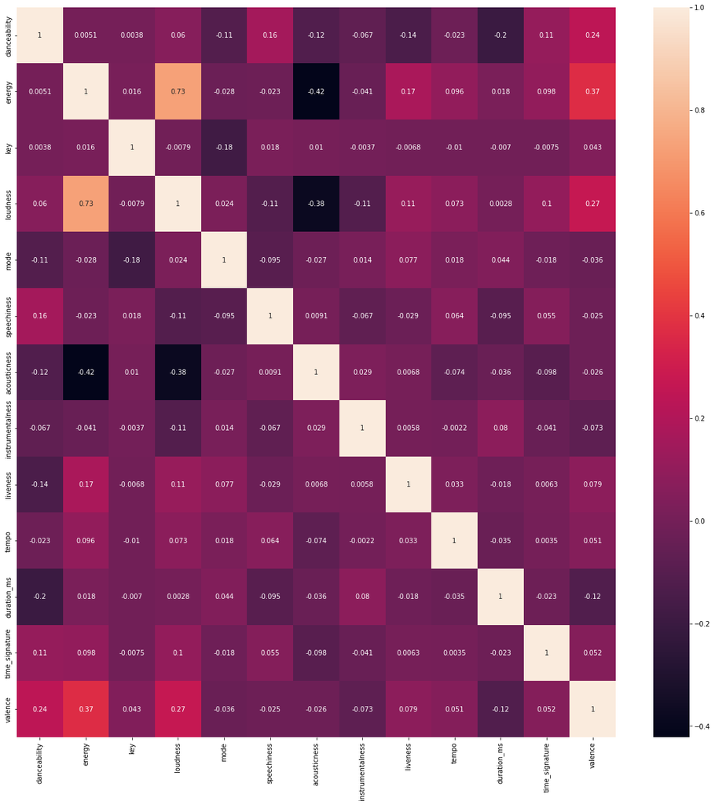

```python
plt.figure(figsize=(20,20))
sns.heatmap(corr_matr, annot=True)
plt.show()
```

The correlation graph seems to give more importance on energy, danceability and loudness. This is logical as we expect happier songs (so songs with above average valence) to be more energetic and people to want to dance to them.

### Q2: Predict Valence

Use Machine Learning techniques to predict valence based on track features:

- You will use at least three different methods. For each methods you should ensure that you tune your hyperparameters as best as you can.
- Once you identify the best method and hyperparameters, explain, to the extent that is possible, which features influence the valence metric.
- You will evaluate your predictions on a holdout 20% testing dataset.

```python
import sklearn
import pandas as pd
import numpy as np

np.random.seed(42)
%matplotlib inline

import matplotlib.pyplot as plt

import tensorflow as tf
from tensorflow import keras
from tensorflow.keras import optimizers
```

When I tried to install tensorflow I got an error as there was no tensorflow version for Python 3.10. To get past this I created a new virtual environment (assign3_env) with Python 3.8.8 in that where I did a fresh installation of all the needed packages as they can be found in the requirements.txt file. Then, I created a jupyter kernel for that virtual environment following the instructions of this [page](https://queirozf.com/entries/jupyter-kernels-how-to-add-change-remove).

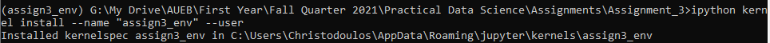

Having set up the libraries I need, let's now start using some models.

Firstly, I'll do a Minimum Viable Product. So, I'll just create a model with no hyperparameter tuning to see that everything can run smoothly. I choose the Decision Tree Regressor as my regressor here.

```python
from sklearn.pipeline import Pipeline
from sklearn.model_selection import train_test_split
from sklearn.preprocessing import StandardScaler
from sklearn.tree import DecisionTreeRegressor
from sklearn.model_selection import cross_val_score, KFold, GridSearchCV
```

X contains the features I'll be using to predict y. I chose all the features except for time_signature based on the results of Q1.

```python
X = df[['danceability', 'energy', 'key', 'loudness', 'mode', 'speechiness', 'acousticness', 'instrumentalness', 'liveness', 'tempo', 'duration_ms']]
```

```python
y = df['valence']
```

As always, it is really important to split our data to train and test data. For our case, we will use 20% of our data as a validation set and in the end we will have a test set that we will use to get the final score for our metric.

```python
X_train, X_test, y_train, y_test = train_test_split(X, y, test_size=0.2, shuffle=True, random_state=42)
```

We initialize our model here.

```python
model = DecisionTreeRegressor()
```

We fit the model to our data.

```python
model.fit(X_train, y_train)
```

```
DecisionTreeRegressor()
```

And here we use cross validation score to get a metric of how good our model is.

```python
cross_val_score(model, X_test, y_test, cv=10)
```

```
array([-0.40634691, -0.36018218, -0.40427474, -0.37538865, -0.53283661,
       -0.61615335, -0.3642965 , -0.09482089, -0.37924784, -0.26051442])
```

Since, we are interested in the *mean absolute error* we take a look at the documentation to see if this metric is implemented for cross_val_score. Below, the available metrics are shown.

```python
sorted(sklearn.metrics.SCORERS.keys())
```

```
['accuracy',
 'adjusted_mutual_info_score',
 'adjusted_rand_score',
 'average_precision',
 'balanced_accuracy',
 'completeness_score',
 'explained_variance',
 'f1',
 'f1_macro',
 'f1_micro',
 'f1_samples',
 'f1_weighted',
 'fowlkes_mallows_score',
 'homogeneity_score',
 'jaccard',
 'jaccard_macro',
 'jaccard_micro',
 'jaccard_samples',
 'jaccard_weighted',
 'max_error',
 'mutual_info_score',
 'neg_brier_score',
 'neg_log_loss',
 'neg_mean_absolute_error',
 'neg_mean_absolute_percentage_error',
 'neg_mean_gamma_deviance',
 'neg_mean_poisson_deviance',
 'neg_mean_squared_error',
 'neg_mean_squared_log_error',
 'neg_median_absolute_error',
 'neg_root_mean_squared_error',
 'normalized_mutual_info_score',
 'precision',
 'precision_macro',
 'precision_micro',
 'precision_samples',
 'precision_weighted',
 'r2',
 'rand_score',
 'recall',
 'recall_macro',
 'recall_micro',
 'recall_samples',
 'recall_weighted',
 'roc_auc',
 'roc_auc_ovo',
 'roc_auc_ovo_weighted',
 'roc_auc_ovr',
 'roc_auc_ovr_weighted',
 'top_k_accuracy',
 'v_measure_score']
```

We choose the *neg_mean_absolute_error* as this metric corresponds to the mean absolute error.

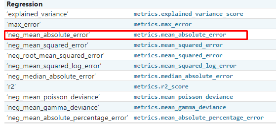

```python
-np.mean(cross_val_score(model, X_test, y_test, cv=10, scoring='neg_mean_absolute_error'))
```

```
0.19187170324390307
```

```python
from sklearn.metrics import mean_absolute_error
```

```python
y_pred = model.predict(X_test)
mean_absolute_error(y_test, y_pred)
```

```
0.17605965417867436
```

So, above we built our first model for the regression task at hand. Now, let's build the methods that we are going to actually use. We choose to implement:

- Random Forest Regressor
- XGBoost Regressor
- Neural Network

These methods are generally considered as the most powerful, so we are going to try them and optimize the parameters for each one.

###### Random Forest Regressor

Let's do a random forest with no optimisation.

```python
from sklearn.ensemble import RandomForestRegressor

model = RandomForestRegressor(random_state=42)
model.fit(X_train, y_train)
y_pred = model.predict(X_test)
mean_absolute_error(y_test, y_pred)
```

```
0.13242974531700288
```

Now, let's use a simple pipeline with a Scaler(it is not needed here as we are using trees so no scaling is required, but as a demonstration) and our regressor.

Then for our hyperparameter tuning, we use a param_grid list that has a list of hyperparameters so we can find the optimal. These hyperparameters are for our RandomForestRegressor, the rgr in the pipeline, so we need to pay attention and write them as rgr__name_of_parameter.

We then create the model and with the GridSearchCV we look for the best hyperparameters for this model.

> Note: I created a column transformer in the pipeline that the only thing it does is to choose the variables I want to use for the training and the prediction phase later. That way, I will simply have to run the model and the pipeline will take care of all the preprocessing needed.

```python
from sklearn.compose import ColumnTransformer

cols = ['danceability', 'energy', 'key', 'loudness', 'mode', 'speechiness', 'acousticness', 'instrumentalness', 'liveness', 'tempo', 'duration_ms']

pipe = Pipeline([
    ("selector", ColumnTransformer([
        ("selector", "passthrough", cols)
    ], remainder="drop")),
    ('scaler', StandardScaler()),
    ('rgr', RandomForestRegressor(random_state=42))
])

param_grid = {
    'rgr__n_estimators': [250],
    'rgr__max_depth': [5, 10, 20]
}

cv = KFold(n_splits=5, shuffle=True, random_state=42)

model_forest = GridSearchCV(pipe, param_grid, n_jobs=2, cv=cv)

model_forest.fit(X_train, y_train)
```

```
GridSearchCV(cv=KFold(n_splits=5, random_state=42, shuffle=True),
             estimator=Pipeline(steps=[('selector',
                                        ColumnTransformer(transformers=[('selector',
                                                                         'passthrough',
                                                                         ['danceability',
                                                                          'energy',
                                                                          'key',
                                                                          'loudness',
                                                                          'mode',
                                                                          'speechiness',
                                                                          'acousticness',
                                                                          'instrumentalness',
                                                                          'liveness',
                                                                          'tempo',
                                                                          'duration_ms'])])),
                                       ('scaler', StandardScaler()),
                                       ('rgr',
                                        RandomForestRegressor(random_state=42))]),
             n_jobs=2,
             param_grid={'rgr__max_depth': [5, 10, 20],
                         'rgr__n_estimators': [250]})
```

```python
model_forest.best_estimator_
```

```
Pipeline(steps=[('selector',
                 ColumnTransformer(transformers=[('selector', 'passthrough',
                                                  ['danceability', 'energy',
                                                   'key', 'loudness', 'mode',
                                                   'speechiness',
                                                   'acousticness',
                                                   'instrumentalness',
                                                   'liveness', 'tempo',
                                                   'duration_ms'])])),
                ('scaler', StandardScaler()),
                ('rgr',
                 RandomForestRegressor(max_depth=20, n_estimators=250,
                                       random_state=42))])
```

```python
y_pred = model_forest.predict(X_test)
mean_absolute_error(y_test, y_pred)
```

```
0.13238445079608177
```

I tried a lot of combinations in the param_grid, with a trail by error approach. Basically I started with 50, 100, 200 estimators and depth of 5, 10, 20, 30. The best model had 200 estimators and 20 depth so then I tried 200, 250, 300 estimators and 10, 20, 30 depth. I got 250 estimators and 20 depth as best in this iteration, tried different depths for 250 estimators and got again 20 depth so I believe that the best estimator for the Random Forest Regressor is the one with hyperparameters close to.

- n_estimators: 250
- max_depth: 20

Nevertheless, optimising these hyperparameters didn't give us any actual improvement here than the default RandomForestRegressor.

Let's check the importances of our features based on this model.

```python
rgr = model_forest.best_estimator_.named_steps.rgr

importances = rgr.feature_importances_

std = np.std([tree.feature_importances_ for tree in rgr.estimators_],
             axis=0)

indices = np.argsort(importances)[::-1]

for f in range(len(df.columns)-2):
    print("%d. feature %d %s (%f)" % (f + 1, indices[f],
                                      df.columns[indices[f]],
                                      importances[indices[f]]))
```

```
1. feature 1 energy (0.214897)
2. feature 0 danceability (0.142935)
3. feature 6 acousticness (0.102288)
4. feature 8 liveness (0.091427)
5. feature 5 speechiness (0.090614)
6. feature 10 duration_ms (0.089188)
7. feature 9 tempo (0.089082)
8. feature 3 loudness (0.080569)
9. feature 7 instrumentalness (0.048198)
10. feature 2 key (0.040918)
11. feature 4 mode (0.009884)
```

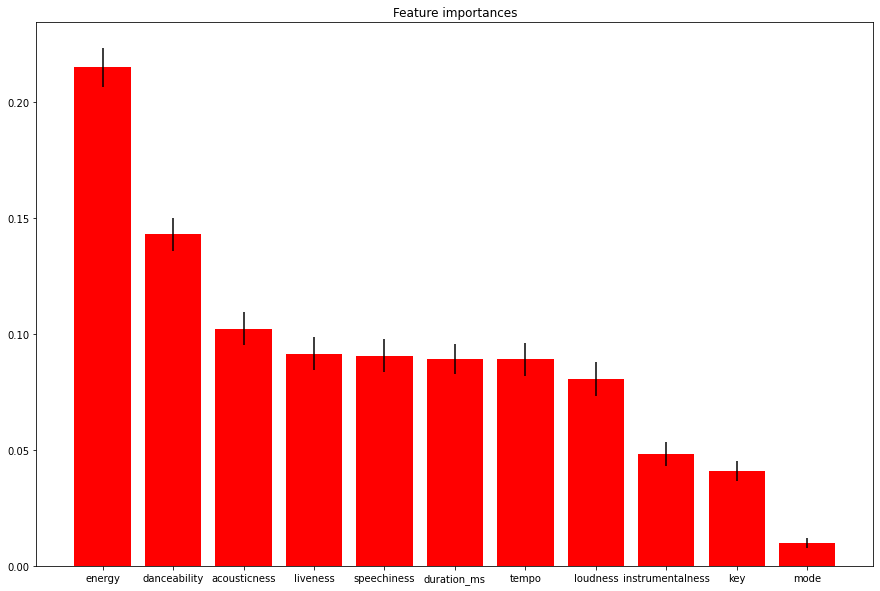

```python
plt.figure(figsize=(15, 10))
plt.title("Feature importances")
plt.bar(range(len(df.columns)-2), importances[indices],
        tick_label=[df.columns[x] for x in indices],
        color="r", yerr=std[indices], align="center")
plt.show()
```

As it is to be expected energy and danceability are still the most important features.

###### XGBooster Regressor

Following we have the xgboost model. Let's take a look at the hyperparameters that it has.

```python
import xgboost as xgb

xgb_reg = xgb.XGBRegressor()

sorted(xgb_reg.get_params().keys())
```

```
['base_score',
 'booster',
 'colsample_bylevel',
 'colsample_bynode',
 'colsample_bytree',
 'enable_categorical',
 'gamma',
 'gpu_id',
 'importance_type',
 'interaction_constraints',
 'learning_rate',
 'max_delta_step',
 'max_depth',
 'min_child_weight',
 'missing',
 'monotone_constraints',
 'n_estimators',
 'n_jobs',
 'num_parallel_tree',
 'objective',
 'predictor',
 'random_state',
 'reg_alpha',
 'reg_lambda',
 'scale_pos_weight',
 'subsample',
 'tree_method',
 'validate_parameters',
 'verbosity']
```

```python
xgb_reg.fit(X_train, y_train)
mean_absolute_error(y_test, xgb_reg.predict(X_test))
```

```
0.1408632092074274
```

We choose to find the optimal model by trying to optimise number of estimators, choose the appropriate tree method and the depth of the trees.

```python
pipe = Pipeline([
    ("selector", ColumnTransformer([
        ("selector", "passthrough", cols)
    ], remainder="drop")),
    ('rgr', xgb_reg)
])

param_grid = {
    'n_estimators': [50, 100],
    'tree_method': ['auto', 'exact', 'approx', 'hist'],
    'max_depth': list(range(5, 11))
}

cv = KFold(n_splits=5, shuffle=True, random_state=42)

model_xgb = GridSearchCV(xgb_reg, param_grid, n_jobs=2, cv=cv)

model_xgb.fit(X_train, y_train)
```

```
GridSearchCV(cv=KFold(n_splits=5, random_state=42, shuffle=True),
             estimator=XGBRegressor(base_score=0.5, booster='gbtree',
                                    colsample_bylevel=1, colsample_bynode=1,
                                    colsample_bytree=1,
                                    enable_categorical=False, gamma=0,
                                    gpu_id=-1, importance_type=None,
                                    interaction_constraints='',
                                    learning_rate=0.300000012, max_delta_step=0,
                                    max_depth=6, min_child_weight=1,
                                    missing=nan, monotone_constraints='()',
                                    n_estimators=100, n_jobs=4,
                                    num_parallel_tree=1, predictor='auto',
                                    random_state=0, reg_alpha=0, reg_lambda=1,
                                    scale_pos_weight=1, subsample=1,
                                    tree_method='exact', validate_parameters=1,
                                    verbosity=None),
             n_jobs=2,
             param_grid={'max_depth': [5, 6, 7, 8, 9, 10],
                         'n_estimators': [50, 100],
                         'tree_method': ['auto', 'exact', 'approx', 'hist']})
```

```python
model_xgb.best_params_
```

```
{'max_depth': 5, 'n_estimators': 100, 'tree_method': 'approx'}
```

```python
mean_absolute_error(y_test, model_xgb.predict(X_test))
```

```
0.14204629986001882
```

Again, despite searching for the optimal hyperparameters, we don't get better results than the default model.

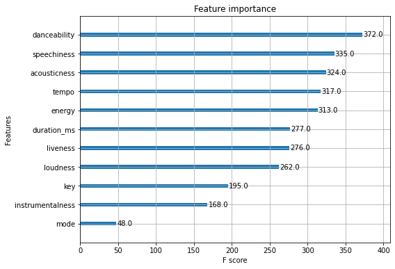

```python
fig = plt.figure(figsize=(8, 6))
xgb.plot_importance(model_xgb.best_estimator_, ax = fig.gca())
```

From the xgboost model we see that danceability is the most important feature.

###### Neural Network

Now, let's build a deep neural network to see if we can get better results than the previous algorithms.

For this neural network I used 5 dense layers (1 input layer, 1 output layer and 3 hidden). The first layer has 11 neurons as is the number of the variables I am using.

I used a normalizer to normalize the data (duration_ms takes really high values). Also, set an ExponentialDecay scheduler for the learning rate so it will be adjusted based on epoch.

To counter overfitting I used some dropout layers that will randomly ignore nodes so the network won't overfit to the train data.

```python
from tensorflow.keras import layers
from tensorflow.keras.layers.experimental import preprocessing
from tensorflow.keras import regularizers

BATCH_SIZE = 128
EPOCHS = 100

normalizer = preprocessing.Normalization()
normalizer.adapt(np.array(X_train))

initial_learning_rate = 0.001
lr_schedule = tf.keras.optimizers.schedules.ExponentialDecay(
    initial_learning_rate,
    decay_steps=100000,
    decay_rate=0.96,
    staircase=True)

def build_compile_model():
    model = keras.Sequential([
        normalizer,
        layers.Dense(11, activation='relu'),
        layers.Dropout(0.2),
        layers.Dense(256, activation='relu', kernel_regularizer=regularizers.l2(0.001)),
        layers.Dropout(0.2),
        layers.Dense(128, activation='relu'),
        layers.Dropout(0.2),
        layers.Dense(64, activation='relu'),
        layers.Dropout(0.2),
        layers.Dense(1)
    ])

    model.compile(loss='mean_absolute_error',
                optimizer=optimizers.Adam(learning_rate=lr_schedule))

    return model

model_nn = build_compile_model()
```

Here we fit the model keeping its history.

```python
history = model_nn.fit(X_train,
             y_train,
             batch_size=BATCH_SIZE,
             epochs=EPOCHS,
             verbose=1,
             validation_split=0.2)
```

And now we plot the model's loss and validation loss to see that indeed there was no or minimal overfitting.

```python
def plot_loss(history):
    plt.plot(history.history['loss'], label='loss')
    plt.plot(history.history['val_loss'], label='val_loss')
    plt.xlabel('Epoch')
    plt.ylabel('Error')
    plt.legend()
    plt.grid(True)
```

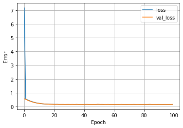

```python
plot_loss(history)
```

```python
model_nn.summary()
```

```
Model: "sequential_86"
_________________________________________________________________
 Layer (type)                Output Shape              Param #
=================================================================
 normalization_77 (Normaliza  (None, 11)               23
 tion)

 dense_295 (Dense)           (None, 11)                132

 dropout_43 (Dropout)        (None, 11)                0

 dense_296 (Dense)           (None, 256)               3072

 dropout_44 (Dropout)        (None, 256)               0

 dense_297 (Dense)           (None, 128)               32896

 dropout_45 (Dropout)        (None, 128)               0

 dense_298 (Dense)           (None, 64)                8256

 dropout_46 (Dropout)        (None, 64)                0

 dense_299 (Dense)           (None, 1)                 65

=================================================================
Total params: 44,444
Trainable params: 44,421
Non-trainable params: 23
_________________________________________________________________
```

I tried a lot of layer combinations, activation functions, learning rates, etc but couldn't get mean absolute errors less than 0.145 without seriously overfitting. At some instance, by adding more layers and neurons and doing nothing to prevent overfitting, I got mean absolute error lower than 0.09, but it was obviously overfitting to the data as the validation error was still at 0.15-0.16.

###### Run Random Forest on Test Data

```python
ids = []
with open('spotify_ids.txt') as f:
    for line in f:
        ids.append(line[:-1])
```

```python
ids
```

```
['7lPN2DXiMsVn7XUKtOW1CS',
 '5QO79kh1waicV47BqGRL3g',
 '0VjIjW4GlUZAMYd2vXMi3b',
 '4MzXwWMhyBbmu6hOcLVD49',
 '5Kskr9LcNYa0tpt5f0ZEJx',
 '6tDDoYIxWvMLTdKpjFkc1B',
 '3VT8hOC5vuDXBsHrR53WFh',
 '1xK1Gg9SxG8fy2Ya373oqb',
 '6f3Slt0GbA2bPZlz0aIFXN',
 '3tjFYV6RSFtuktYl3ZtYcq',
 '27OeeYzk6klgBh83TSvGMA',
 '2XIc1pqjXV3Cr2BQUGNBck',
 '60ynsPSSKe6O3sfwRnIBRf',
 '1M4OcYkxAtu3ErzSgDEfoi',
 '3YJJjQPAbDT7mGpX3WtQ9A',
 '5nujrmhLynf4yMoMtj8AQF',
 '1t9WgS8FN0534tLBRwbaxO',
 '7vrJn5hDSXRmdXoR30KgF1',
 '4saklk6nie3yiGePpBwUoc',
 '3FAJ6O0NOHQV8Mc5Ri6ENp',
 '0D75ciM842cdUMKSMfAR9y',
 '35mvY5S1H3J2QZyna3TFe0',
 '6Im9k8u9iIzKMrmV7BWtlF',
 '5YYW3yRktprLRr47WK219Y',
 '7hxHWCCAIIxFLCzvDgnQHX',
 '3VvA1wSxukMLsvXoXtlwWx',
 '1diS6nkxMQc3wwC4G1j0bh',
 '6ft4hAq6yde8jPZY2i5zLr',
 '7qEHsqek33rTcFNT9PFqLf',
 '31qCy5ZaophVA81wtlwLc4',
 '3iw6V4LH7yPj1ESORX9RIN',
 '45bE4HXI0AwGZXfZtMp8JR',
 '02MWAaffLxlfxAUY7c5dvx',
 '1tkg4EHVoqnhR6iFEXb60y',
 '5uEYRdEIh9Bo4fpjDd4Na9',
 '6UelLqGlWMcVH1E5c4H7lY',
 '1J14CdDAvBTE1AJYUOwl6C',
 '6cx06DFPPHchuUAcTxznu9',
 '5YaskwnGDZFDRipaqzbwQx',
 '54bFM56PmE4YLRnqpW6Tha',
 '2vBET2pmrQqafaS6zIaYta',
 '7ytR5pFWmSjzHJIeQkgog4',
 '2Oycxb8QbPkpHTo8ZrmG0B',
 '1yoMvmasuxZfqHEipJhRbp',
 '1rgnBhdG2JDFTbYkYRZAku',
 '2QjOHCTQ1Jl3zawyYOpxh6',
 '4Oun2ylbjFKMPTiaSbbCih',
 ...]
```

```python
features = {}
start = 0
num_tracks = 100

while start < len(ids):
    print(f'getting from {start} to {start+num_tracks}')
    tracks_batch = ids[start:start+num_tracks]
    features_batch = sp.audio_features(tracks_batch)
    features.update({ track_id : track_features
                     for track_id, track_features in zip(tracks_batch, features_batch) })
    start += num_tracks

print(len(features))

df_test = pd.DataFrame.from_dict(features, orient='index')
df_test
```

```
getting from 0 to 100
getting from 100 to 200
getting from 200 to 300
getting from 300 to 400
getting from 400 to 500
getting from 500 to 600
getting from 600 to 700
getting from 700 to 800
getting from 800 to 900
getting from 900 to 1000
getting from 1000 to 1100
getting from 1100 to 1200
1162
```

|  | danceability | energy | key | loudness | mode | speechiness | acousticness | instrumentalness | liveness | valence | tempo | type | id | uri | track_href | analysis_url | duration_ms | time_signature |
| --- | --- | --- | --- | --- | --- | --- | --- | --- | --- | --- | --- | --- | --- | --- | --- | --- | --- | --- |
| 7lPN2DXiMsVn7XUKtOW1CS | 0.585 | 0.436 | 10 | -8.761 | 1 | 0.0601 | 0.72100 | 0.000013 | 0.1050 | 0.132 | 143.874 | audio_features | 7lPN2DXiMsVn7XUKtOW1CS | spotify:track:7lPN2DXiMsVn7XUKtOW1CS | https://api.spotify.com/v1/tracks/7lPN2DXiMsVn... | https://api.spotify.com/v1/audio-analysis/7lPN... | 242014 | 4 |
| 5QO79kh1waicV47BqGRL3g | 0.680 | 0.826 | 0 | -5.487 | 1 | 0.0309 | 0.02120 | 0.000012 | 0.5430 | 0.644 | 118.051 | audio_features | 5QO79kh1waicV47BqGRL3g | spotify:track:5QO79kh1waicV47BqGRL3g | https://api.spotify.com/v1/tracks/5QO79kh1waic... | https://api.spotify.com/v1/audio-analysis/5QO7... | 215627 | 4 |
| 0VjIjW4GlUZAMYd2vXMi3b | 0.514 | 0.730 | 1 | -5.934 | 1 | 0.0598 | 0.00146 | 0.000095 | 0.0897 | 0.334 | 171.005 | audio_features | 0VjIjW4GlUZAMYd2vXMi3b | spotify:track:0VjIjW4GlUZAMYd2vXMi3b | https://api.spotify.com/v1/tracks/0VjIjW4GlUZA... | https://api.spotify.com/v1/audio-analysis/0VjI... | 200040 | 4 |
| 4MzXwWMhyBbmu6hOcLVD49 | 0.731 | 0.573 | 4 | -10.059 | 0 | 0.0544 | 0.40100 | 0.000052 | 0.1130 | 0.145 | 109.928 | audio_features | 4MzXwWMhyBbmu6hOcLVD49 | spotify:track:4MzXwWMhyBbmu6hOcLVD49 | https://api.spotify.com/v1/tracks/4MzXwWMhyBbm... | https://api.spotify.com/v1/audio-analysis/4MzX... | 205090 | 4 |
| 5Kskr9LcNYa0tpt5f0ZEJx | 0.907 | 0.393 | 4 | -7.636 | 0 | 0.0539 | 0.45100 | 0.000001 | 0.1350 | 0.202 | 104.949 | audio_features | 5Kskr9LcNYa0tpt5f0ZEJx | spotify:track:5Kskr9LcNYa0tpt5f0ZEJx | https://api.spotify.com/v1/tracks/5Kskr9LcNYa0... | https://api.spotify.com/v1/audio-analysis/5Ksk... | 205458 | 4 |
| ... | ... | ... | ... | ... | ... | ... | ... | ... | ... | ... | ... | ... | ... | ... | ... | ... | ... | ... |
| 4lUmnwRybYH7mMzf16xB0y | 0.596 | 0.650 | 9 | -5.167 | 1 | 0.3370 | 0.13800 | 0.000000 | 0.1400 | 0.188 | 133.997 | audio_features | 4lUmnwRybYH7mMzf16xB0y | spotify:track:4lUmnwRybYH7mMzf16xB0y | https://api.spotify.com/v1/tracks/4lUmnwRybYH7... | https://api.spotify.com/v1/audio-analysis/4lUm... | 257428 | 4 |
| 1fzf9Aad4y1RWrmwosAK5y | 0.588 | 0.850 | 4 | -6.431 | 1 | 0.0318 | 0.16800 | 0.002020 | 0.0465 | 0.768 | 93.003 | audio_features | 1fzf9Aad4y1RWrmwosAK5y | spotify:track:1fzf9Aad4y1RWrmwosAK5y | https://api.spotify.com/v1/tracks/1fzf9Aad4y1R... | https://api.spotify.com/v1/audio-analysis/1fzf... | 187310 | 4 |
| 3E3pb3qH11iny6TFDJvsg5 | 0.754 | 0.660 | 0 | -6.811 | 1 | 0.2670 | 0.17900 | 0.000000 | 0.1940 | 0.316 | 83.000 | audio_features | 3E3pb3qH11iny6TFDJvsg5 | spotify:track:3E3pb3qH11iny6TFDJvsg5 | https://api.spotify.com/v1/tracks/3E3pb3qH11in... | https://api.spotify.com/v1/audio-analysis/3E3p... | 209299 | 4 |
| 3yTkoTuiKRGL2VAlQd7xsC | 0.584 | 0.836 | 0 | -4.925 | 1 | 0.0790 | 0.05580 | 0.000000 | 0.0663 | 0.484 | 104.973 | audio_features | 3yTkoTuiKRGL2VAlQd7xsC | spotify:track:3yTkoTuiKRGL2VAlQd7xsC | https://api.spotify.com/v1/tracks/3yTkoTuiKRGL... | https://api.spotify.com/v1/audio-analysis/3yTk... | 202204 | 4 |
| 4JE6agBLHGA5TaF6FlqfBD | 0.331 | 0.450 | 10 | -5.362 | 1 | 0.0340 | 0.36500 | 0.004640 | 0.2200 | 0.180 | 123.829 | audio_features | 4JE6agBLHGA5TaF6FlqfBD | spotify:track:4JE6agBLHGA5TaF6FlqfBD | https://api.spotify.com/v1/tracks/4JE6agBLHGA5... | https://api.spotify.com/v1/audio-analysis/4JE6... | 218755 | 4 |

1162 rows × 18 columns

Since random forest was our best model we will use it to predict valence for the above 1162 songs.

```python
y_pred = model_forest.predict(df_test)
```

```python
mean_absolute_error(df_test['valence'], y_pred)
```

```
0.14071737286609584
```